# hw3-hope-131

Evan Hope

4/19/2022

Downloading appropriate packages…

```r
library(ggplot2)
library(tidyverse)
library(tidymodels)
library(corrplot)
library(ggthemes)
library(ISLR2)
library(discrim)
library(poissonreg)
library(corrr)
library(klaR)
tidymodels_prefer()
```

Reading in the data and setting the seed…

```r
set.seed(8888)

titanic_data <- read.csv("C:/Users/Ordai/OneDrive/Desktop/School/Stats/PSTAT 131/hw3-131-Hope/titanic.csv")
```

We must now change “survived” and “plclass” to factors while also reordering the levels of the survived.

```r
titanic_data$survived <- factor(titanic_data$survived, levels = c("Yes", "No"))

titanic_data$pclass <- factor(titanic_data$pclass)

is.factor(titanic_data$survived)
```

```
## [1] TRUE
```

```r
is.factor(titanic_data$pclass)
```

```
## [1] TRUE
```

Question 1.) splitting the data

```r
titanic_data_split <- initial_split(titanic_data, prop = 0.70, strata = survived)

titanic_train <- training(titanic_data_split)
titanic_test <- testing(titanic_data_split)
```

It is good to use stratified sampling here because we are dealing with qualitative data that can produce different average values.

Question 2.) Distribution of ‘survived’

```r
titanic_train$survived
```

[output not shown]

[output cut: 21 more lines]

After observing the training set, we can easily see that more people didnt survive than did survive. Given that there are only two possible outcomes, the survived variable has a binomial distributed with some probability ‘p’ that the passenger survives.

Question 3.) Correlation Matrix

Plotting our correlation matrix for the cont. variables only…

```r
corrlate_titanic <- titanic_train %>%
  select(-survived, -pclass, -name, -sex, -ticket, -embarked, -cabin) %>%
  correlate()
```

```
##
## Correlation method: 'pearson'
## Missing treated using: 'pairwise.complete.obs'
```

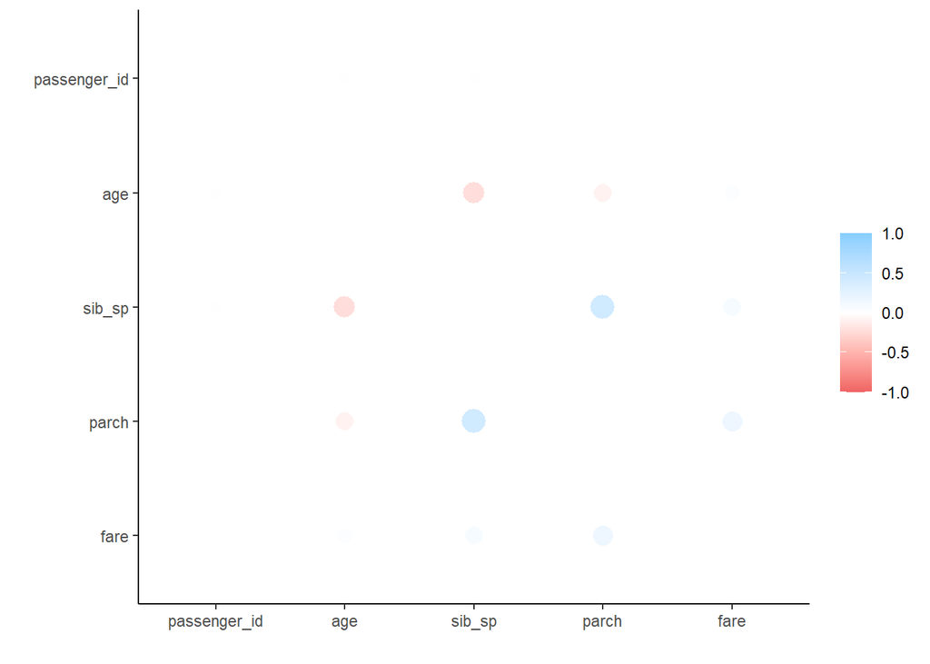

```r
rplot(corrlate_titanic)
```

By the looks of it there are TWO distinct correlations. 1.) # of siblings/spouses and age in the red direction.

This makes sense as the number of siblings and spouses increases, the ages should typically be younger as this indicates a child of a family.

Otherwise the age may represent the (typically older) age of the husband if the number represents the spouse.

2.) # of siblings/spouse and # of parents/children aboard in the blue direction.

For similar reasons above, this correlation should be expected.

Question 4.) Recipe

```r
titanic_survival <- recipe(survived ~ pclass + sex + age + sib_sp + parch + fare, data = titanic_train) %>%
  step_impute_linear(age) %>%
  step_dummy(all_nominal_predictors()) %>%
  step_normalize(all_numeric()) %>%
  step_interact(terms = ~ sex_male:fare) %>%
  step_interact(terms = ~ age:fare)
```

Question 5.) Logistic Regression

Setting up the engine

```r
log_reg <- logistic_reg() %>%
  set_engine("glm") %>%
  set_mode("classification")
```

Setting up the workflow…

```r
log_wkflow <- workflow() %>%
  add_model(log_reg) %>%
  add_recipe(titanic_survival)


#Applying the workflow...

titanic_log_fit <- fit(log_wkflow, titanic_train)
```

Lets view the results.

```r
titanic_log_fit %>%
  tidy()
```

```
## # A tibble: 10 x 5
##    term            estimate std.error statistic  p.value
##    <chr>              <dbl>     <dbl>     <dbl>    <dbl>
##  1 (Intercept)       0.661      0.111     5.97  2.35e- 9
##  2 age               0.746      0.138     5.40  6.79e- 8
##  3 sib_sp            0.394      0.141     2.80  5.04e- 3
##  4 parch             0.0316     0.113     0.280 7.80e- 1
##  5 fare             -0.0384     0.160    -0.240 8.11e- 1
##  6 pclass_X2         0.565      0.146     3.86  1.15e- 4
##  7 pclass_X3         1.26       0.183     6.86  6.86e-12
##  8 sex_male          1.22       0.114    10.7   8.33e-27
##  9 sex_male_x_fare   0.139      0.152     0.914 3.61e- 1
## 10 age_x_fare       -0.263      0.129    -2.03  4.23e- 2
```

Question 6. 7. and 8.) Repeat 5….

Linear Discriminant Analysis

```r
# Engine
linear_disc_analysis <- discrim_linear() %>%
  set_engine("MASS") %>%
  set_mode("classification")

#Setting up the workflow...

linear_disc_wkflow <- workflow() %>%
  add_model(linear_disc_analysis) %>%
  add_recipe(titanic_survival)


#Applying the workflow...

titanic_linear_disc_fit <- fit(linear_disc_wkflow, titanic_train)
```

Quadratic Discriminant Analysis

```r
# Engine
quad_disc_analysis <- discrim_quad() %>%
  set_engine("MASS") %>%
  set_mode("classification")

#Setting up the workflow...

quad_disc_wkflow <- workflow() %>%
  add_model(quad_disc_analysis) %>%
  add_recipe(titanic_survival)


#Applying the workflow...

titanic_quad_disc_fit <- fit(quad_disc_wkflow, titanic_train)
```

Naive Bayes Model

```r
# Engine
naive_bayes_model <- naive_Bayes() %>%
  set_engine("klaR") %>%
  set_mode("classification") %>%
  set_args(usekernel = FALSE)

#Setting up the workflow...

naive_bayes_wkflow <- workflow() %>%
  add_model(naive_bayes_model) %>%
  add_recipe(titanic_survival)


#Applying the workflow...

titanic_naive_bayes_fit <- fit(naive_bayes_wkflow, titanic_train)
```

Question 9.)

Calculating our accuracies for all 4 models

```r
log_reg_acc <- augment(titanic_log_fit, new_data = titanic_train) %>%
  accuracy(truth = survived, estimate = .pred_class)

disc_linear_acc <- augment(titanic_linear_disc_fit, new_data = titanic_train) %>%
  accuracy(truth = survived, estimate = .pred_class)

quad_disc_acc <- augment(titanic_quad_disc_fit, new_data = titanic_train) %>%
  accuracy(truth = survived, estimate = .pred_class)

naive_bayes_acc <- augment(titanic_naive_bayes_fit, new_data = titanic_train) %>%
  accuracy(truth = survived, estimate = .pred_class)
```

And now comparing…

```r
accuracies <- c(log_reg_acc$.estimate, disc_linear_acc$.estimate,
                quad_disc_acc$.estimate, naive_bayes_acc$.estimate)
models <- c("Logistic Regression", "LDA", "QDA", "Naive Bayes")
results <- tibble(accuracies = accuracies, models = models)
results %>%
  arrange(-accuracies)
```

```
## # A tibble: 4 x 2
##   accuracies models
##        <dbl> <chr>
## 1      0.801 Logistic Regression
## 2      0.782 QDA
## 3      0.775 LDA
## 4      0.772 Naive Bayes
```

Based off this display of accuracy scores, logistic regression appears to have the highest accuracy!

Question 10.) Using the logistic regression model…

```r
predict(titanic_log_fit, new_data = titanic_test, type = "prob")
```

```
## # A tibble: 268 x 2
##    .pred_Yes .pred_No
##        <dbl>    <dbl>
##  1    0.919    0.0808
##  2    0.630    0.370
##  3    0.919    0.0815
##  4    0.306    0.694
##  5    0.0369   0.963
##  6    0.786    0.214
##  7    0.475    0.525
##  8    0.104    0.896
##  9    0.473    0.527
## 10    0.211    0.789
## # ... with 258 more rows
```

Putting it into a confusion matrix…

```r
augment(titanic_log_fit, new_data = titanic_test) %>%
  conf_mat(truth = survived, estimate = .pred_class)
```

```
##           Truth
## Prediction Yes  No
##        Yes  82  21
##        No   21 144
```

Now we will look at the ROC curve and find the area under the curve.

First: ROC plot

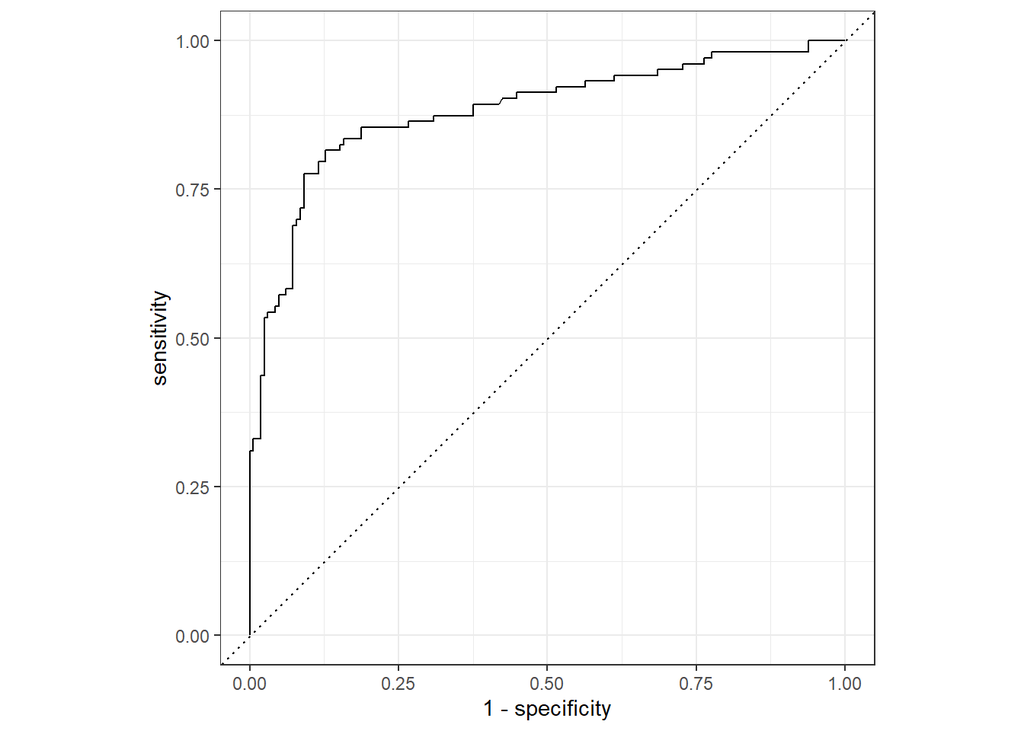

```r
augment(titanic_log_fit, new_data = titanic_test) %>%
  roc_curve(survived, .pred_Yes) %>%
  autoplot()
```

Now for the AUC:

```r
augment(titanic_log_fit, new_data = titanic_test) %>%
  roc_auc(survived, .pred_Yes)
```

```
## # A tibble: 1 x 3
##   .metric .estimator .estimate
##   <chr>   <chr>          <dbl>
## 1 roc_auc binary         0.882
```

As we can see, our testing accuracy was higher than our training accuracy! The reason I think this happens is because there are missing values in the data that could be distorting it a bit.